# **DATA MINING - Projet Botanic**

#### **Target - MONTANTREMISE_CAT** :

- Modalités : 4 (Q1_inferieur_0.5, Q2_entre_0.5_6, Q3_entre_6_12, Q4_superieur_12)
- Modalité de référence : Q4_superieur_12

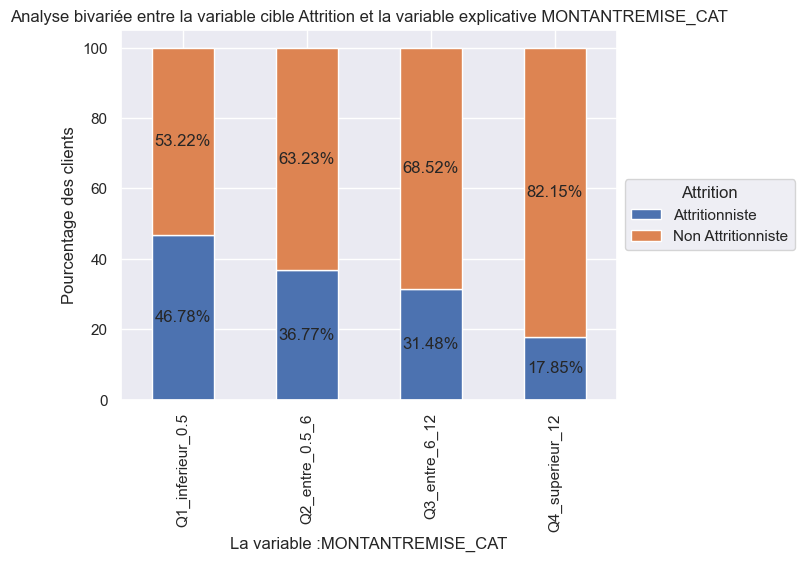

```
La modalité de référence pour la variable -- MONTANTREMISE_CAT -- est celle qui représente le pourcentage le plus élevé pour les clients non attritionnistes :
 ---------------------------------------------------------------------------------------------------
Y_attrition        Attritionniste  Non Attritionniste       All
MONTANTREMISE_CAT
Q1_inferieur_0.5         0.116961            0.133042  0.250002
Q2_entre_0.5_6           0.091936            0.158071  0.250007
Q3_entre_6_12            0.078708            0.171286  0.249993
Q4_superieur_12          0.044621            0.205377  0.249998
All                      0.332225            0.667775  1.000000
/n
Statistique de test observée : 21644.637239923657
p-value du test : 0.0
dégré de liberté : 3
MONTANTREMISE_CAT--- H0 Rejetée, la variable explicative MONTANTREMISE_CAT est susceptible d'être liée à la variable cible.
 ---------------------------------------------------------------------------------------------------
```

```python
# Affichage du graphique
col="MONTANTREMISE_CAT"
GraphiqueBarrreStackAnalyse(dfTableAnalyse, col, 'Y_attrition')
```

**Note** :

- **Résultat du test de khi-deux** : H0 Rejetée, la variable explicative est susceptible d'être liée à la variable cible.
- **Interprétation du graphique** :

Les clients les plus attritionnistes sont ceux qui ont le moins de remise (Q1_inferieur_0.5)

- **Les 2 variables sont probablement en liaison.**

#### **Target - TOTAL_CAT** :

- Modalités : 4 (Q1_inferieur_41, Q2_entre_41_77, Q3_entre_77_129, Q4_superieur_129)
- Modalité de référence : Q4_superieur_129

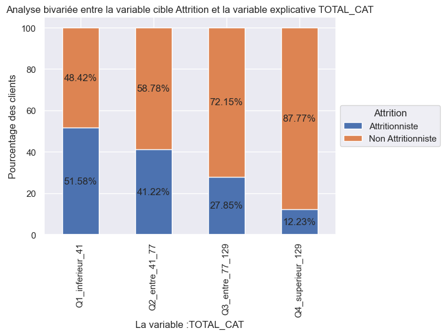

```
La modalité de référence pour la variable -- TOTAL_CAT -- est celle qui représente le pourcentage le plus élevé pour les clients non attritionnistes :
 ---------------------------------------------------------------------------------------------------
Y_attrition       Attritionniste  Non Attritionniste       All
TOTAL_CAT
Q1_inferieur_41         0.128968            0.121064  0.250032
Q2_entre_41_77          0.103045            0.146928  0.249973
Q3_entre_77_129         0.069634            0.180363  0.249998
Q4_superieur_129        0.030578            0.219420  0.249998
All                     0.332225            0.667775  1.000000
/n
Statistique de test observée : 43225.027890609956
p-value du test : 0.0
dégré de liberté : 3
TOTAL_CAT----------- H0 Rejetée, la variable explicative TOTAL_CAT est susceptible d'être liée à la variable cible.
 ---------------------------------------------------------------------------------------------------
```

```python
# Affichage du graphique
col="TOTAL_CAT"
GraphiqueBarrreStackAnalyse(dfTableAnalyse, col, 'Y_attrition')
```

**Note** :

- **Résultat du test de khi-deux** : H0 Rejetée, la variable explicative est susceptible d'être liée à la variable cible.
- **Interprétation du graphique** :

Les clients les plus attritionnistes sont ceux qui ont un total inférieur à 41.

- **Les 2 variables sont probablement en liaison.**

#### **Target - MARGESORTIE_CAT** :

- Modalités : 4 (Q1_inferieur_20, Q2_entre_20_37, Q3_entre_37_61, Q4_superieur_61)
- Modalité de référence : Q4_superieur_61

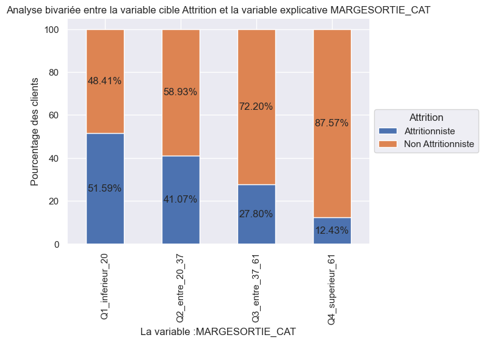

```
La modalité de référence pour la variable -- MARGESORTIE_CAT -- est celle qui représente le pourcentage le plus élevé pour les clients non attritionnistes :
 ---------------------------------------------------------------------------------------------------
Y_attrition      Attritionniste  Non Attritionniste       All
MARGESORTIE_CAT
Q1_inferieur_20        0.128970            0.121030  0.250000
Q2_entre_20_37         0.102679            0.147330  0.250009
Q3_entre_37_61         0.069501            0.180504  0.250005
Q4_superieur_61        0.031075            0.218911  0.249986
All                    0.332225            0.667775  1.000000
/n
Statistique de test observée : 42731.792294655555
p-value du test : 0.0
dégré de liberté : 3
MARGESORTIE_CAT----- H0 Rejetée, la variable explicative MARGESORTIE_CAT est susceptible d'être liée à la variable cible.
 ---------------------------------------------------------------------------------------------------
```

```python
# Affichage du graphique
col="MARGESORTIE_CAT"
GraphiqueBarrreStackAnalyse(dfTableAnalyse, col, 'Y_attrition')
```

**Note** :

- **Résultat du test de khi-deux** : H0 Rejetée, la variable explicative est susceptible d'être liée à la variable cible.
- **Interprétation du graphique** : Les clients les plus attritionnistes sont ceux qui ont une marge de sortie inférieur à 20.
- **Les 2 variables sont probablement en liaison.**

#### **Target - U1_CAT** :

- U1 : Jardin et potager balcon et terrasse
- Modalités : 4 (Q1_moins de 4, Q2_Entre 4 et 9, Q3_Entre 10 et 18, Q4_Superieur à 18)
- Modalité de référence : Q4_Superieur à 18

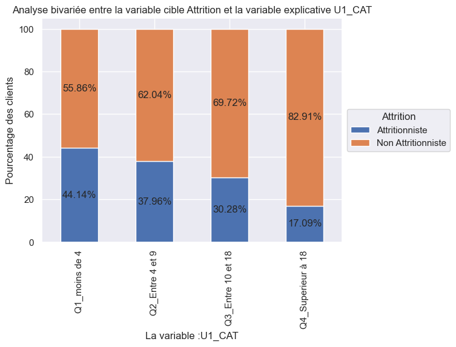

```
La modalité de référence pour la variable -- U1_CAT -- est celle qui représente le pourcentage le plus élevé pour les clients non attritionnistes :
 ---------------------------------------------------------------------------------------------------
Y_attrition        Attritionniste  Non Attritionniste       All
U1_CAT
Q1_moins de 4            0.136024            0.172153  0.308176
Q2_Entre 4 et 9          0.086337            0.141130  0.227467
Q3_Entre 10 et 18        0.070023            0.161246  0.231268
Q4_Superieur à 18        0.039842            0.193247  0.233088
All                      0.332225            0.667775  1.000000
/n
Statistique de test observée : 20748.630556303608
p-value du test : 0.0
dégré de liberté : 3
U1_CAT-------------- H0 Rejetée, la variable explicative U1_CAT est susceptible d'être liée à la variable cible.
 ---------------------------------------------------------------------------------------------------
```

```python
# Affichage du graphique
col="U1_CAT"
GraphiqueBarrreStackAnalyse(dfTableAnalyse, col, 'Y_attrition')
```

**Note** :

- **Résultat du test de khi-deux** : H0 Rejetée, la variable explicative est susceptible d'être liée à la variable cible.
- **Interprétation du graphique** :

Les clients les plus attritionnistes sont ceux qui ont acheté moins de 4 articles.

- **Les 2 variables sont probablement en liaison.**

#### **Target - U2_CAT** :

- U2 : Maison et mobilier
- Modalités : 4 (Q1_moins de 2, Q2_Entre 2 et 3, Q3_Entre 4 et 7, Q4_Superieur à 8)
- Modalité de référence : Q4_Superieur à 8

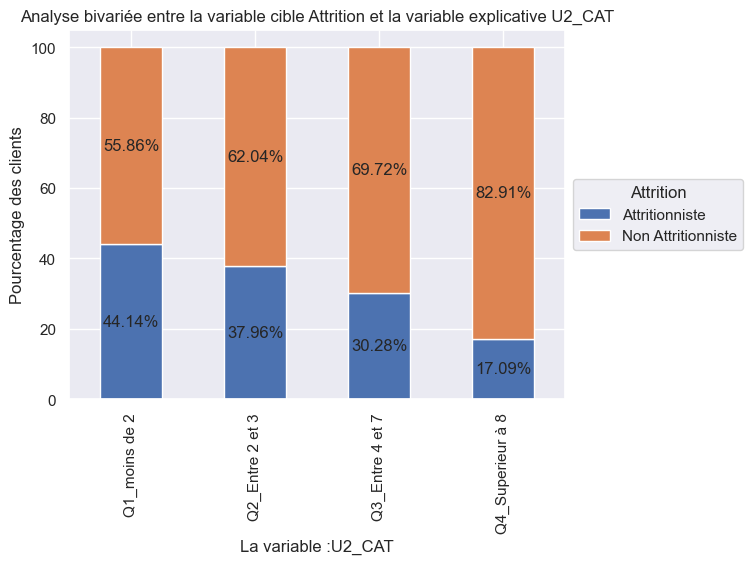

```
La modalité de référence pour la variable -- U2_CAT -- est celle qui représente le pourcentage le plus élevé pour les clients non attritionnistes :
 ---------------------------------------------------------------------------------------------------
Y_attrition       Attritionniste  Non Attritionniste       All
U2_CAT
Q1_moins de 2           0.136024            0.172153  0.308176
Q2_Entre 2 et 3         0.086337            0.141130  0.227467
Q3_Entre 4 et 7         0.070023            0.161246  0.231268
Q4_Superieur à 8        0.039842            0.193247  0.233088
All                     0.332225            0.667775  1.000000
/n
Statistique de test observée : 20748.630556303608
p-value du test : 0.0
dégré de liberté : 3
U2_CAT-------------- H0 Rejetée, la variable explicative U2_CAT est susceptible d'être liée à la variable cible.
 ---------------------------------------------------------------------------------------------------
```

```python
# Affichage du graphique
col="U2_CAT"
GraphiqueBarrreStackAnalyse(dfTableAnalyse, col, 'Y_attrition')
```

**Note** :

- **Résultat du test de khi-deux** : H0 Rejetée, la variable explicative est susceptible d'être liée à la variable cible.
- **Interprétation du graphique** : Les clients les plus attritionnistes sont ceux qui ont acheté moins de 2 articles.
- **Les 2 variables sont probablement en liaison.**

#### **Target - U3_CAT** :

- U3 : Animalerie
- Modalités : 2 (Q1_moins de 5, Q2_Superieur à 5)
- Modalité de référence : Q2_Superieur à 5

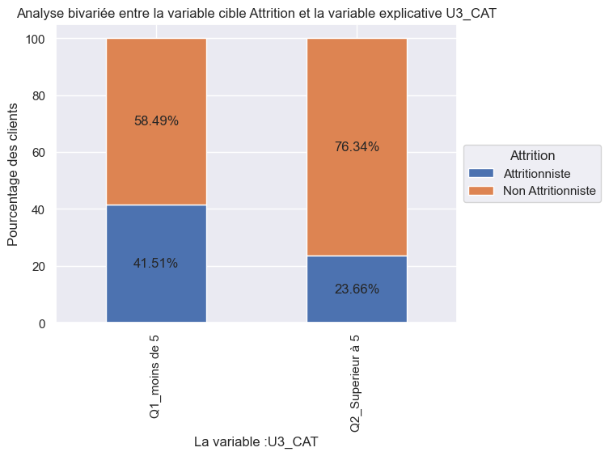

```
La modalité de référence pour la variable -- U3_CAT -- est celle qui représente le pourcentage le plus élevé pour les clients non attritionnistes :
 ---------------------------------------------------------------------------------------------------
Y_attrition       Attritionniste  Non Attritionniste       All
U3_CAT
Q1_moins de 5           0.222361            0.313282  0.535643
Q2_Superieur à 5        0.109864            0.354493  0.464357
All                     0.332225            0.667775  1.000000
/n
Statistique de test observée : 15746.13297954727
p-value du test : 0.0
dégré de liberté : 1
U3_CAT-------------- H0 Rejetée, la variable explicative U3_CAT est susceptible d'être liée à la variable cible.
 ---------------------------------------------------------------------------------------------------
```

```python
# Affichage du graphique
col="U3_CAT"
GraphiqueBarrreStackAnalyse(dfTableAnalyse, col, 'Y_attrition')
```

**Note** :

- **Résultat du test de khi-deux** : H0 Rejetée, la variable explicative est susceptible d'être liée à la variable cible.
- **Interprétation du graphique** : Les clients les plus attritionnistes sont ceux qui ont acheté moins de 5 articles.
- **Les 2 variables sont probablement en liaison.**

#### **Target - U4_CAT** :

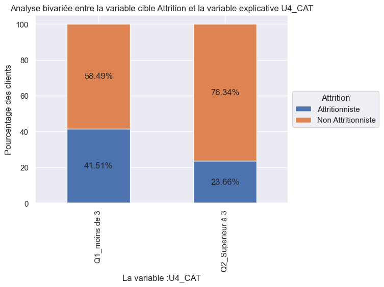

```
La modalité de référence pour la variable -- U4_CAT -- est celle qui représente le pourcentage le plus élevé pour les clients non attritionnistes :
 ---------------------------------------------------------------------------------------------------
Y_attrition       Attritionniste  Non Attritionniste       All
U4_CAT
Q1_moins de 3           0.222361            0.313282  0.535643
Q2_Superieur à 3        0.109864            0.354493  0.464357
All                     0.332225            0.667775  1.000000
/n
Statistique de test observée : 15746.13297954727
p-value du test : 0.0
dégré de liberté : 1
U4_CAT-------------- H0 Rejetée, la variable explicative U4_CAT est susceptible d'être liée à la variable cible.
 ---------------------------------------------------------------------------------------------------
```

```python
# Affichage du graphique
col="U4_CAT"
GraphiqueBarrreStackAnalyse(dfTableAnalyse, col, 'Y_attrition')
```

**Note** :

- **Résultat du test de khi-deux** : H0 Rejetée, la variable explicative est susceptible d'être liée à la variable cible.
- **Interprétation du graphique** :

Les clients les plus attritionnistes sont ceux qui ont acheté moins de 3 articles.

- **Les 2 variables sont probablement en liaison.**

### **Rapport de l'Analyse Bivariée :**

- Observation de la repartition, de la distribution des effectifs pour chacune des variables qualitatives par rapport à la variable cible.
- Identification d'une modalité de référence pour chacune des variables qualitatives.
- Test du Khi-deux effectué et le calcul de la P-Values :
  - la P-Values de toutes les variables explicatives a été rejetée, cela montre que les variables explicatives ont une liaison avec la variable cible. Cependant, pour savoir si la variable explicative est réellement significativement influente (si elle explique réellement la variable cible), nous observerons les effectifs des modalités de chaque variables explicatifs. La question est de savoir si la variable explicative est réellement significativement influente (Si elle explique réellement la variable cible).
  - **La P-Value, nous permet de savoir si la variable explicative est réellement significativement influente (Si elle explique réellement la variable cible)**.
  - ***Le Test du Khi-deux : Permet de mesurer la significativité de la variable explicative sur la variable cible. Le test du Khi-deux prend en compte les effectifs correspondants. Les effectifs assoient la significativité de la variable explicative sur la variable cible. La significativité est calculée non seulement par l'écart mais aussi par l'effectif***.
  - ***Le Test du khi-deux mesure l'écart à la reférence (l'écart doit être le plus loin possible)***.

## **7- Enregistrement du fichier en fichier Parquet**

```python
# Création de l'environnement de travail
filepathparquet = 'data/dfTableAnalyse.parquet'
```

```python
# **Sauvegarde du jeu de données dans un fichier parquet**</font>
# Les fichiers parquet sont des fichiers organisés par colonnes, et en format compressés. Le type des colonnes est conservé. C'est aussi un format accessible à Spark, Hive, Presto / Trino, Apache Drill, Synapse Analytics dans Azure ...

# magasin.to_parquet(path = 'data/magasin.parquet',
dfTableAnalyse.to_parquet(path = filepathparquet,
                            engine = 'auto',
                            compression = 'gzip',
                            index = None)
```

# **SUITE : Fichier Botanic_Phase 2 et 3**

# **Phase 2 et 3 - Le Pre-processing (le pre-traitement des données) et la Modélisation**